# Lab04: Chi Square and Power Analyses

# Chunk 1: Load libraries, data and set a working directory

1.1) Load `tidyverse` library 1.2) Load the “HumanHemoglobinElevation.csv” dataset and call it `Hemoglobin` 1.3) Load the “MalariaAndMosquitoFeeding.csv” dataset and call it ‘Malaria’ 1.4) What is the structure of both datasets?

```
## 'data.frame':    1962 obs. of  4 variables:
##  $ id        : Factor w/ 1962 levels "Andean.male1",..: 259 1075 1186 1297 1408 1519 1630 1741 1852 260 ...
##  $ hemoglobin: num  10.4 11.2 11.7 11.8 11.9 ...
##  $ population: Factor w/ 4 levels "Andes","Ethiopia",..: 4 4 4 4 4 4 4 4 4 4 ...
##  $ elevation : Factor w/ 2 levels "High","Low": 2 2 2 2 2 2 2 2 2 2 ...
```

```
## 'data.frame':    261 obs. of  2 variables:
##  $ infectionStatus   : Factor w/ 2 levels "infected","uninfected": 1 1 1 1 1 1 1 1 1 1 ...
##  $ multipleBloodMeals: Factor w/ 2 levels "multiple","single": 2 2 2 2 2 2 2 2 2 2 ...
```

# Chunk 2: Filter hemoglobin data by country

2.1) What is the global mean of hemoglobin levels? 2.2) What is the population mean by country? Hint use `filter()`

```
##              id         hemoglobin       population   elevation
##  Andean.male1 :   1   Min.   :10.40   Andes   :  71   High: 226
##  Andean.male10:   1   1st Qu.:14.80   Ethiopia: 128   Low :1736
##  Andean.male11:   1   Median :15.45   Tibet   :  59
##  Andean.male12:   1   Mean   :15.56   USA     :1704
##  Andean.male13:   1   3rd Qu.:16.15
##  Andean.male14:   1   Max.   :25.06
##  (Other)      :1956
```

[output not shown]

```
##                 id         hemoglobin       population   elevation
##  US.Sea.level1   :   1   Min.   :10.40   Andes   :   0   High:   0
##  US.Sea.level10  :   1   1st Qu.:14.75   Ethiopia:   0   Low :1704
##  US.Sea.level100 :   1   Median :15.40   Tibet   :   0
##  US.Sea.level1000:   1   Mean   :15.38   USA     :1704
##  US.Sea.level1001:   1   3rd Qu.:16.00
##  US.Sea.level1002:   1   Max.   :18.65
##  (Other)         :1698
```

```
##              id       hemoglobin       population elevation
##  Andean.male1 : 1   Min.   :14.96   Andes   :71   High:71
##  Andean.male10: 1   1st Qu.:18.03   Ethiopia: 0   Low : 0
##  Andean.male11: 1   Median :19.11   Tibet   : 0
##  Andean.male12: 1   Mean   :19.23   USA     : 0
##  Andean.male13: 1   3rd Qu.:20.18
##  Andean.male14: 1   Max.   :25.06
##  (Other)      :65
```

```
##                  id        hemoglobin       population  elevation
##  Ethiopian.male1  :  1   Min.   :12.65   Andes   :  0   High:96
##  Ethiopian.male10 :  1   1st Qu.:14.99   Ethiopia:128   Low :32
##  Ethiopian.male100:  1   Median :15.84   Tibet   :  0
##  Ethiopian.male101:  1   Mean   :15.86   USA     :  0
##  Ethiopian.male102:  1   3rd Qu.:16.79
##  Ethiopian.male103:  1   Max.   :18.85
##  (Other)          :122
```

```
##               id       hemoglobin       population elevation
##  Tibetan.male1 : 1   Min.   :13.03   Andes   : 0   High:59
##  Tibetan.male10: 1   1st Qu.:14.85   Ethiopia: 0   Low : 0
##  Tibetan.male11: 1   Median :15.53   Tibet   :59
##  Tibetan.male12: 1   Mean   :15.71   USA     : 0
##  Tibetan.male13: 1   3rd Qu.:16.38
##  Tibetan.male14: 1   Max.   :19.96
##  (Other)       :53
```

# Chunk 3: Plot the data

3.1) Plot the distirbutions of hemoglobin levels by population as a density plot (set alpha to 0.5) 3.2) Plot the distirbutions of hemoglobin levels by population as a boxplot 3.3) Plot the distirbutions of hemoglobin levels by population as a strip plot inside a violin plot~! (set alpha of points to 0.25 and color by population) 3.4) Use a comment # to describe the different plots. What are the pros and cons of each way of visualizing distributions?

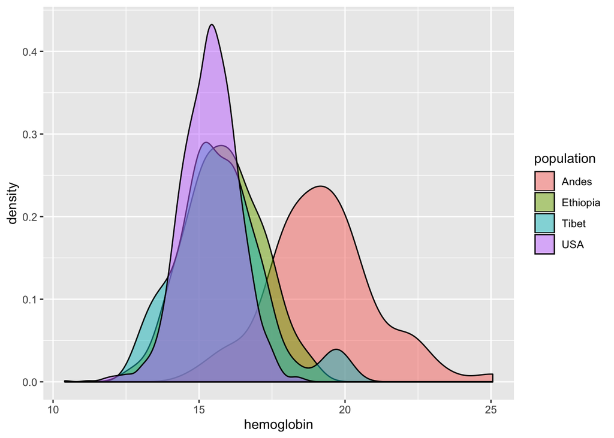

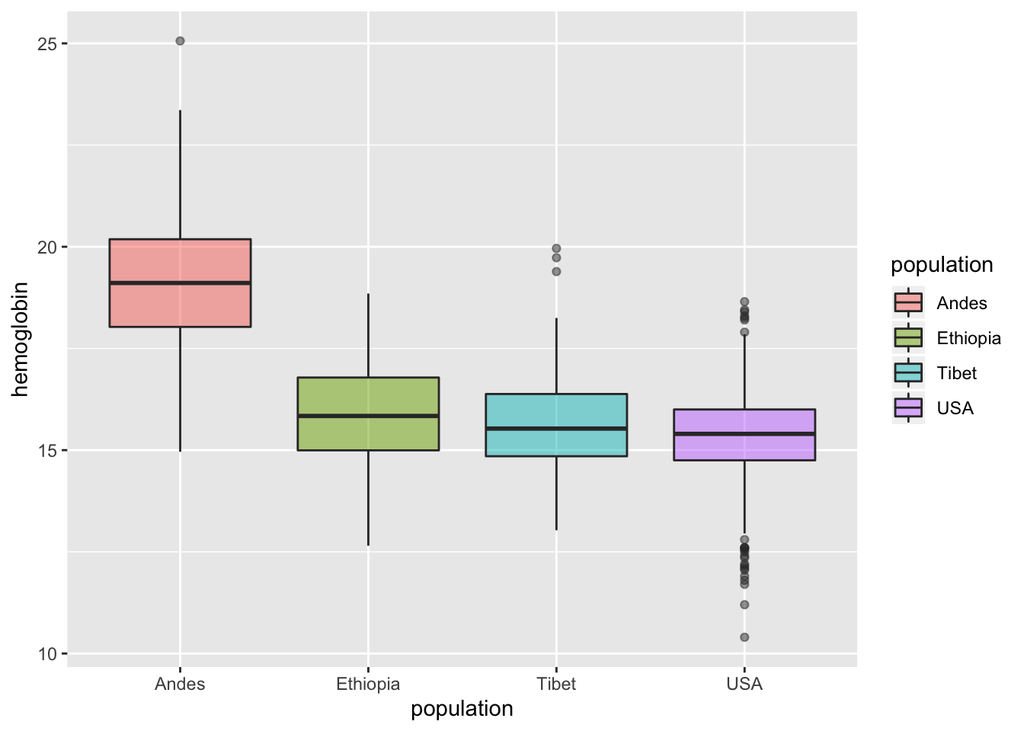

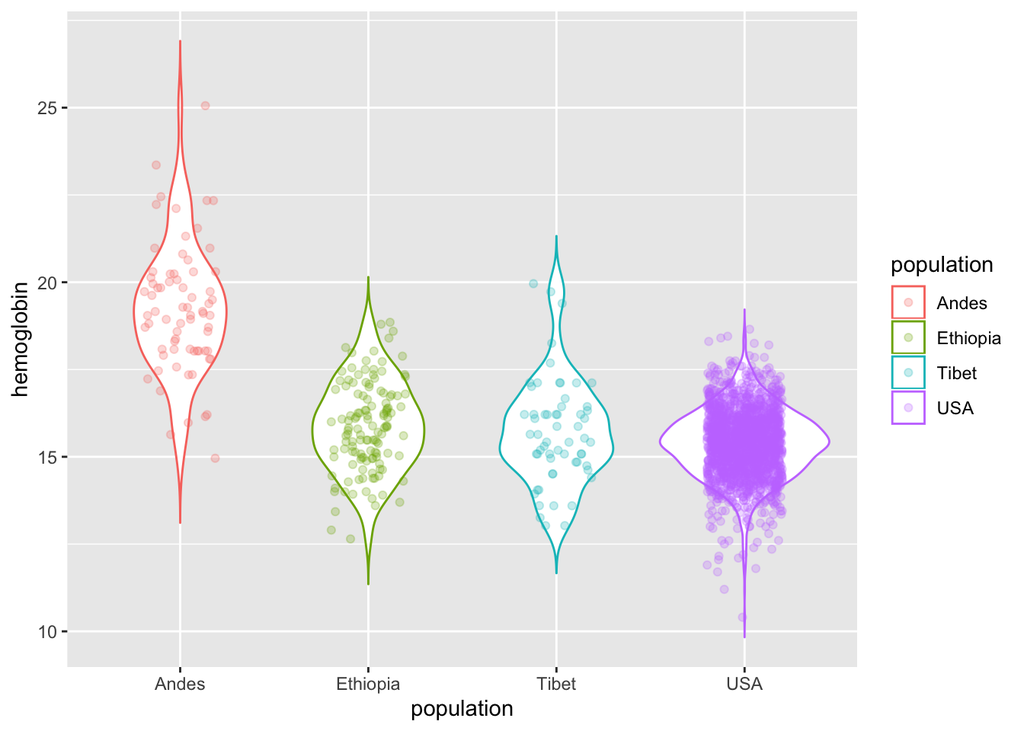

# Chunk 4: Plotting 2 categorical vairables with Hemoglobin Data

4.1) Create a stacked bar plot of the number of observations in each country by elevation category 4.2) Create a 100% stacked bar plot of the percentage of observations in each country by elevation category 4.3) How do these plots differ? Use #comment to provide your answer

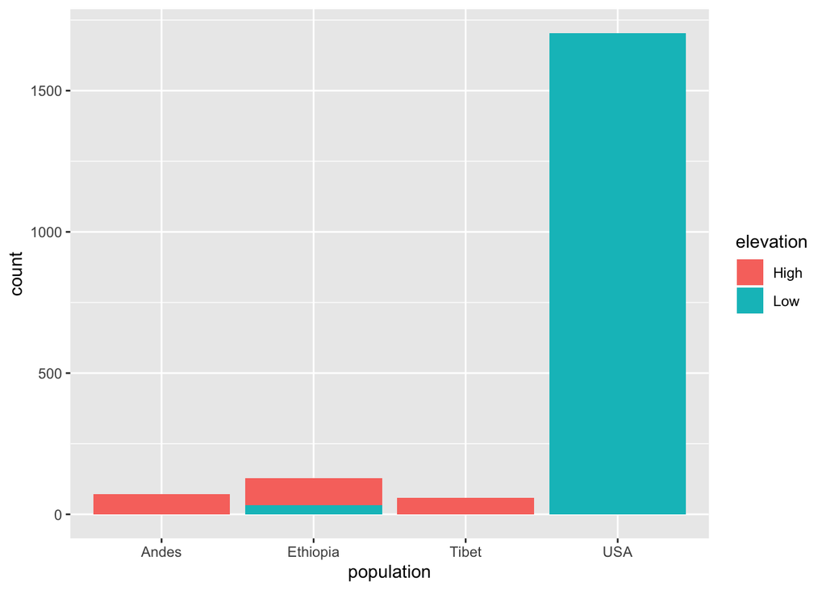

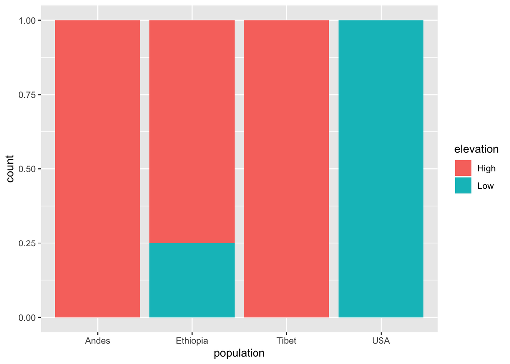

# Chunk 5: Plotting 2 categorical vairables with Malaria Data

```
5.1) Create a stacked bar plot for the Malaria data set. Make sure the correct variables are on the X axis and Y axis. Note: the experiment is testing whether infected mosquitoes are more likely to bite multiple people than uninfected mosquitoes.
```

5.2) Create a 100% stacked bar plot of the percentage of observations for the Malaria data set. Using a #comment, which figure do you think is better at communicating patters?

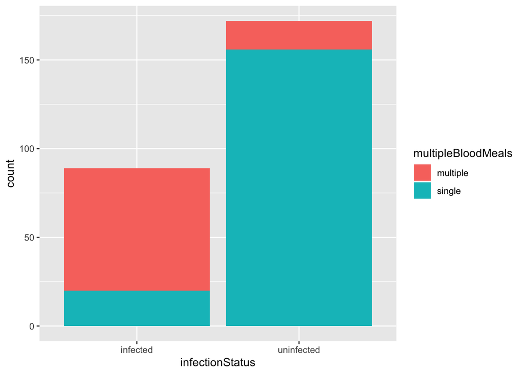

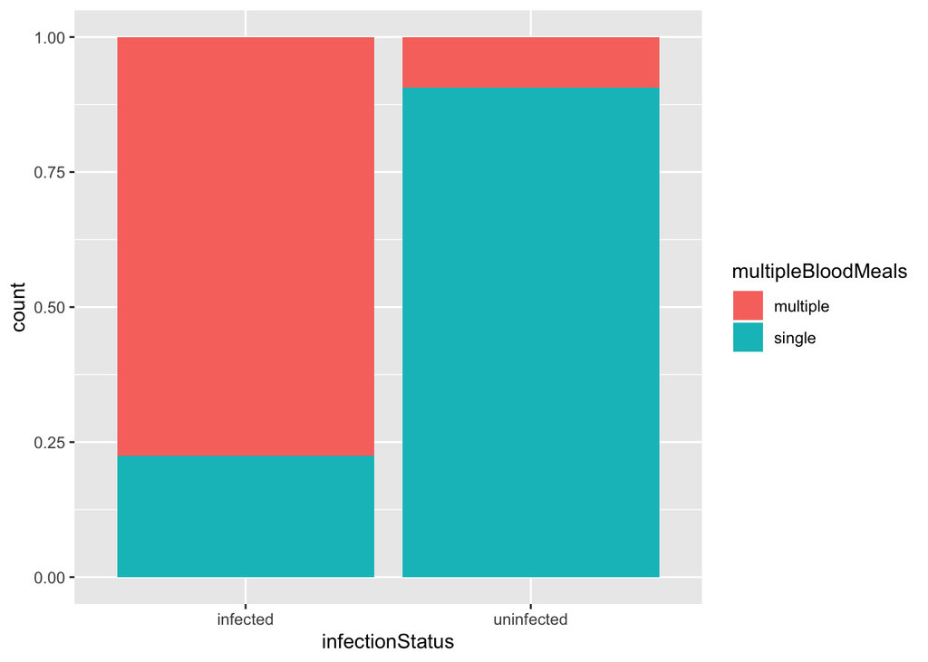

# Chunk 6: Chi-square test of Independence: 6.1) Hemoglobin data: You are interested in the association between the number of participants in the study within each country and elevation. What are the null and alternative hypotheses that can be tested? Use the # to comment

6.2) create a contingency table of obervations in different populations vs. elevations

6.3) calculate a chi-square test testing the association betweenthe number of participants in the study within each country and elevation.

6.4) Interpret the results. Which of your hypotheses is supported?

6.5) repeat the procedure in 4.1-4.4 with the Malaria data to test the association between infection status of the mosquitos and whether the mosquito had a single feeding or multiple feeding

```
##
##            High  Low
##   Andes      71    0
##   Ethiopia   96   32
##   Tibet      59    0
##   USA         0 1704
```

```
##
##  Pearson's Chi-squared test
##
## data:  table1
## X-squared = 1726.5, df = 3, p-value < 2.2e-16
```

```
##
##              multiple single
##   infected         69     20
##   uninfected       16    156
```

```
##
##  Pearson's Chi-squared test with Yates' continuity correction
##
## data:  table2
## X-squared = 121.23, df = 1, p-value < 2.2e-16
```

# Chunk 7: Power Analysis

7.1) load the `pwr` library 7.2) Start with Hemoglobin data: create a proportional table of obervations in different populations vs. elevations 7.3) Calculate the power for each of the four countries, given the proportions of observations and sample sizes for each country and a significance level of 0.05. Which countries have the highest power? Why do you think this is the case? 7.4) What happens when you decrease the expected significance level to 0.01. Interpret these results. 7.5) What happens when you decrease half the number of observations collected in each population but retain a significance level of 0.5. Interpret these results. 7.6) Even when power is > 0.8, why might this study be flawed?

```
##
##                  High        Low
##   Andes    0.03618756 0.00000000
##   Ethiopia 0.04892966 0.01630989
##   Tibet    0.03007136 0.00000000
##   USA      0.00000000 0.86850153
```

```
## [1] 0.3827934
```

```
##
##      proportion power calculation for binomial distribution (arcsine transformation)
##
##               h = 0.3827934
##               n = 71
##       sig.level = 0.05
##           power = 0.8971559
##     alternative = two.sided
```

```
## [1] 0.1899708
```

```
##
##      proportion power calculation for binomial distribution (arcsine transformation)
##
##               h = 0.1899708
##               n = 128
##       sig.level = 0.05
##           power = 0.5750949
##     alternative = two.sided
```

```
## [1] 0.3485841
```

```
##
##      proportion power calculation for binomial distribution (arcsine transformation)
##
##               h = 0.3485841
##               n = 59
##       sig.level = 0.05
##           power = 0.7634878
##     alternative = two.sided
```

```
## [1] -2.399422
```

```
##
##      proportion power calculation for binomial distribution (arcsine transformation)
##
##               h = 2.399422
##               n = 1704
##       sig.level = 0.05
##           power = 1
##     alternative = two.sided
```

```
##
##                multiple     single
##   infected   0.26436782 0.07662835
##   uninfected 0.06130268 0.59770115
```

```
## [1] 0.5191098
```

```
##
##              multiple single
##   infected         69     20
##   uninfected       16    156
```

```
##
##      proportion power calculation for binomial distribution (arcsine transformation)
##
##               h = 0.5191098
##               n = 89
##       sig.level = 0.05
##           power = 0.9983446
##     alternative = two.sided
```

```
## [1] -1.267072
```

```
##
##      proportion power calculation for binomial distribution (arcsine transformation)
##
##               h = 1.267072
##               n = 172
##       sig.level = 0.05
##           power = 1
##     alternative = two.sided
```